# hypergeometric_distribution.R

Hincal

2019-11-25

```r
options(warn=-1)
```

**HyperGeometric distribution models sampling without replacement, we take a ball from a cup and dont throw it back,so each time we try to find the “success” ( here success is getting black ball for example") with remaining count of balls. So the probability depends on previous drawnings.** **lets create a vector with fails and successes(here ones are success or desired output, getting black ball for example)**

```r
observations <- c(0,0,1,0,1,1,0,1,0,0,0,0)
```

**define hypergeometric distribution function**  
**N : Total number of observations**  
**R : Total Number of desired output in vector**  
**n : trial count**  
**y : desired output or success**

```r
hyper_func <- function(N,R,n,y){
  temp<-((factorial(R) / (factorial(y) * factorial(R-y))) * (factorial(N-R) / (factorial(n-y) * factorial(N-R-n+y)))) / (factorial(N) / (factorial(n) * factorial(N-n)))
  return(temp)
}
```

**suppose that we have 12 balls in a cup and 4 of them is black, what is the probability of getting one black in first draw ?**

```r
hyper_func(length(observations),4,1,1)
```

```
## [1] 0.3333333
```

**lets look at the event from another aspect, what is the probability of gettin one black ball in one draw or two draw ?**

```r
for (i in 1:2){
  sumx <- sum(observations)
  len <- length(observations)
  print(hyper_func(len,sumx,i,1))
}
```

```
## [1] 0.3333333
## [1] 0.4848485
```

**what is the probability of gettin one black ball when we make one to five draw ?**

```r
for (i in 1:5){
  sumx <- sum(observations)
  len <- length(observations)
  print(hyper_func(len,sumx,i,1))
}
```

```
## [1] 0.3333333
## [1] 0.4848485
## [1] 0.5090909
## [1] 0.4525253
## [1] 0.3535354
```

**what if to 12 draw ?**

```r
for (i in 1:12){
  sumx <- sum(observations)
  len <- length(observations)
  print(hyper_func(len,sumx,i,1))
}
```

```
## [1] 0.3333333
## [1] 0.4848485
## [1] 0.5090909
## [1] 0.4525253
## [1] 0.3535354
## [1] 0.2424242
## [1] 0.1414141
## [1] 0.06464646
## [1] 0.01818182
## [1] NaN
## [1] NaN
## [1] NaN
```

**so lets create another vector which includes successes**

```r
Vec <- c(rep(0, 100), rep(1, 10))

Vec
```

```
##   [1] 0 0 0 0 0 0 0 0 0 0 0 0 0 0 0 0 0 0 0 0 0 0 0 0 0 0 0 0 0 0 0 0 0 0 0
##  [36] 0 0 0 0 0 0 0 0 0 0 0 0 0 0 0 0 0 0 0 0 0 0 0 0 0 0 0 0 0 0 0 0 0 0 0
##  [71] 0 0 0 0 0 0 0 0 0 0 0 0 0 0 0 0 0 0 0 0 0 0 0 0 0 0 0 0 0 0 1 1 1 1 1
## [106] 1 1 1 1 1
```

**lets calculate it for this vector, what is the probability of getting 3 black balls if we make up to 50 draws ?**

```r
result <- NULL
for (i in 1:50){
  sumx <- sum(Vec)
  len <- length(Vec)
  result[i] <- hyper_func(len,sumx,i,3)
  print(result[i])
}
```

```
## [1] NaN
## [1] NaN
## [1] 0.0005560189
## [1] 0.002078575
## [1] 0.004853277
## [1] 0.009059451
## [1] 0.01478694
## [1] 0.0220512
## [1] 0.03080683
## [1] 0.04095958
## [1] 0.05237706
## [1] 0.06489817
## [1] 0.07834136
## [1] 0.09251183
## [1] 0.1072077
```

[output cut: 35 more lines]

**for plotting :** **50 draws to get 3 black balls**

```r
res1<-NULL
for (i in 1:50){
  sumx <- sum(Vec)
  len <- length(Vec)
  res1[i] <- hyper_func(len,sumx,i,3)
}
```

**plot 1**

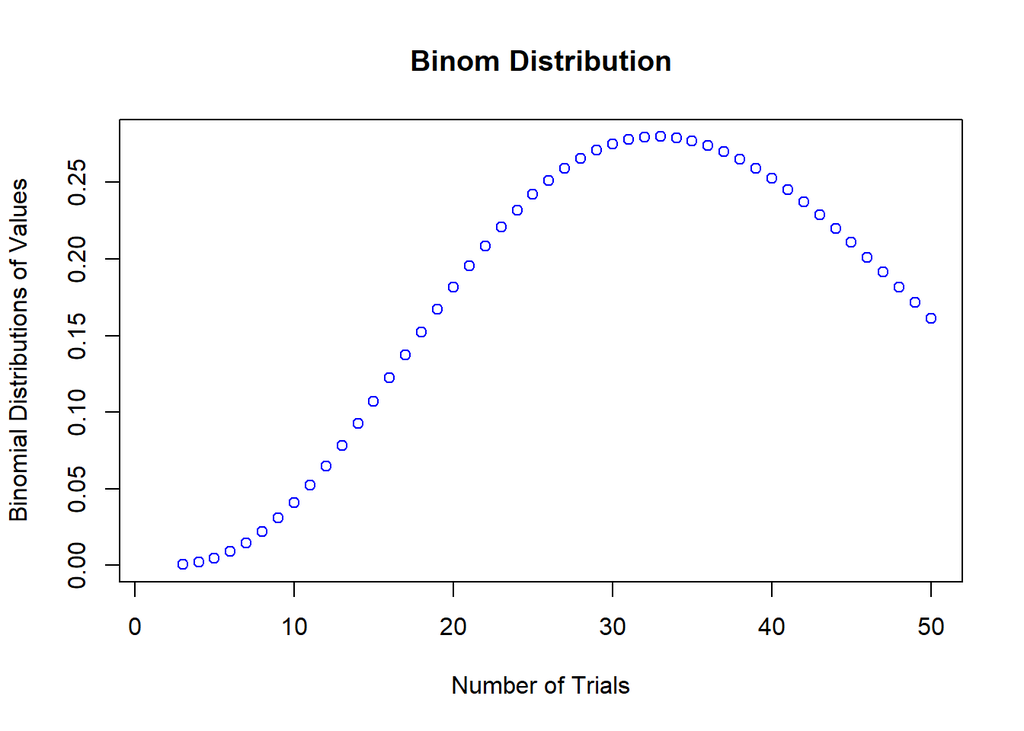

```r
plot(res1,type="b",main="Binom Distribution",ylab="Binomial Distributions of Values", xlab = "Number of Trials",col="blue")
```

**50 draws to get 4 black balls**

```r
res2 <- NULL
for (i in 1:50){
  sumx <- sum(Vec)
  len <- length(Vec)
  res2[i] <- hyper_func(len,sumx,i,4)
}
```

**plot 2**

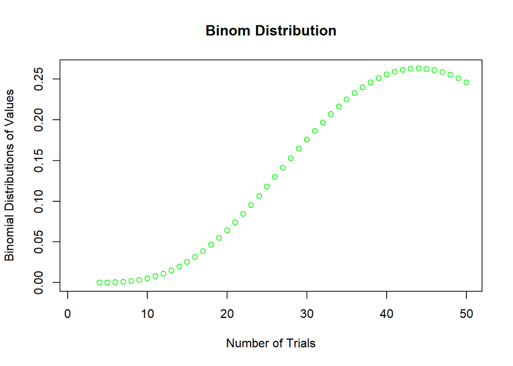

```r
plot(res2,type="b",main="Binom Distribution",ylab="Binomial Distributions of Values", xlab = "Number of Trials",col="green")
```

**60 draws to get 4 black balls**

```r
res3<-NULL
for (i in 1:60){
  sumx <- sum(Vec)
  len <- length(Vec)
  res3[i] <- hyper_func(len,sumx,i,4)
}
```

**plot 3**

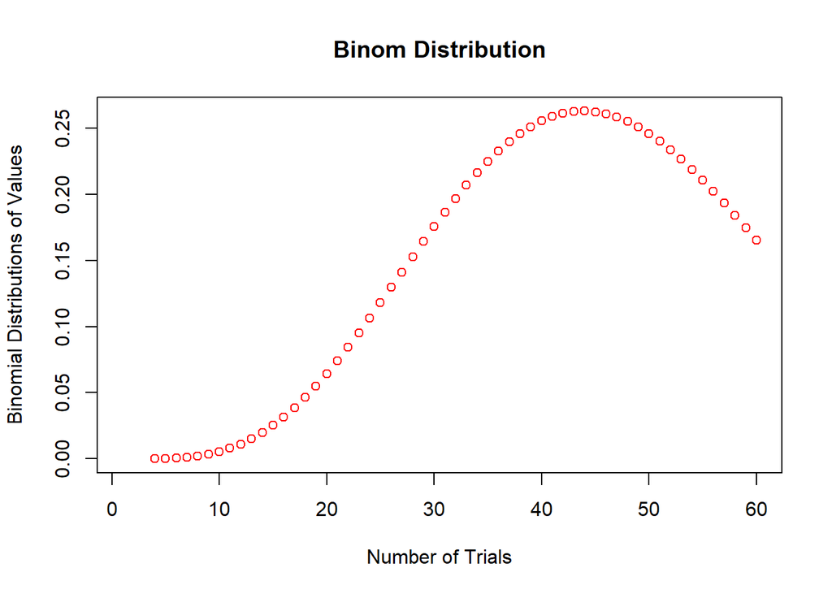

```r
plot(res3,type="b",main="Binom Distribution",ylab="Binomial Distributions of Values", xlab = "Number of Trials",col="red")
```

**#** **80 draws to get 4 black balls**

```r
res4<-NULL
for (i in 1:80){
  sumx <- sum(Vec)
  len <- length(Vec)
  res4[i] <- hyper_func(len,sumx,i,4)
}
```

**plot 4**

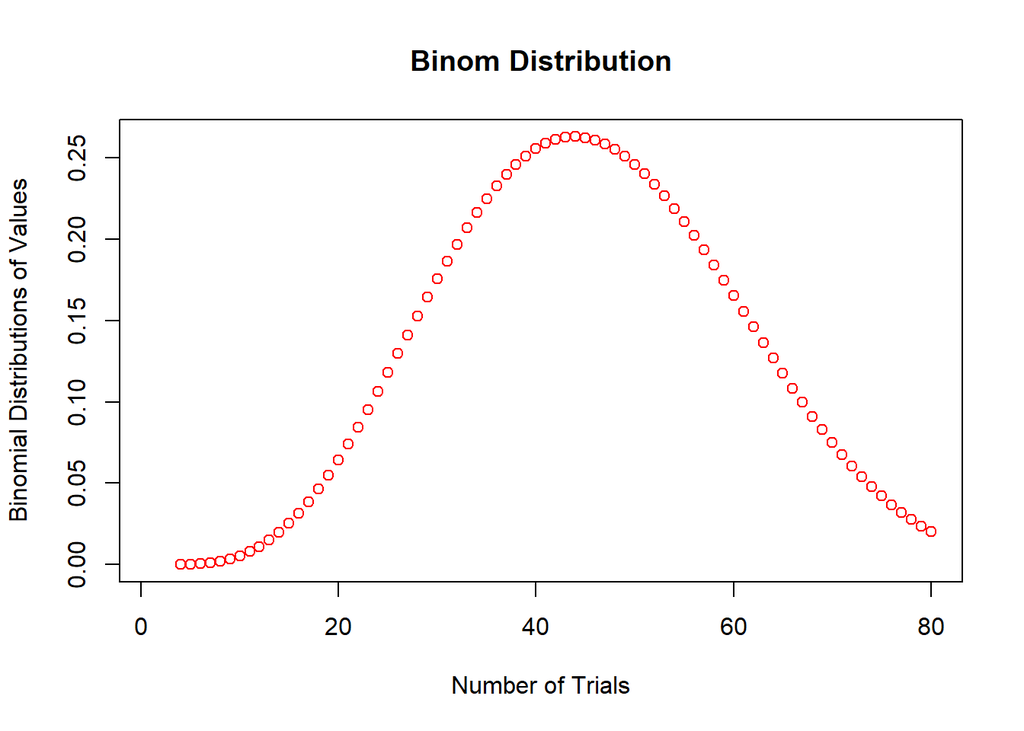

```r
plot(res4,type="b",main="Binom Distribution",ylab="Binomial Distributions of Values", xlab = "Number of Trials",col="red")
```

**90 draws to get 4 black balls**

```r
res5<-NULL
for (i in 1:90){
  sumx <- sum(Vec)
  len <- length(Vec)
  res5[i] <- hyper_func(len,sumx,i,4)
}
```

**plot 5**

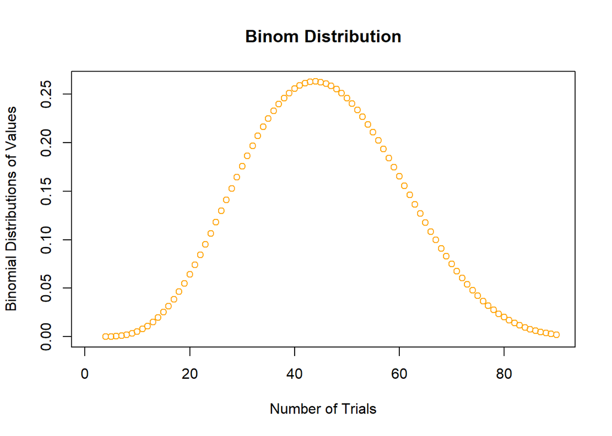

```r
plot(res5,type="b",main="Binom Distribution",ylab="Binomial Distributions of Values", xlab = "Number of Trials",col="orange")
```